# Rep.Res Course Project 1

### 4.Imputing missing values

a.Calculate and report the total number of missing values in the dataset (i.e. the total number of rows with NAs)

```r
totalNAS<-sum(is.na(data$steps))
totalNAS
```

```
## [1] 2304
```

b.Devise a strategy for filling in all of the missing values in the dataset. The strategy does not need to be sophisticated. For example, you could use the mean/median for that day, or the mean for that 5-minute interval, etc.

```r
getMeanStepsPerInterval<-function(interval){
    stepsPerInterval[stepsPerInterval$interval==interval,]$steps
}
```

c.Create a new dataset that is equal to the original dataset but with the missing data filled in.

```r
dataNoNA<-data
for(i in 1:nrow(dataNoNA)){
    if(is.na(dataNoNA[i,]$steps)){
        dataNoNA[i,]$steps <- getMeanStepsPerInterval(dataNoNA[i,]$interval)
    }
}
```

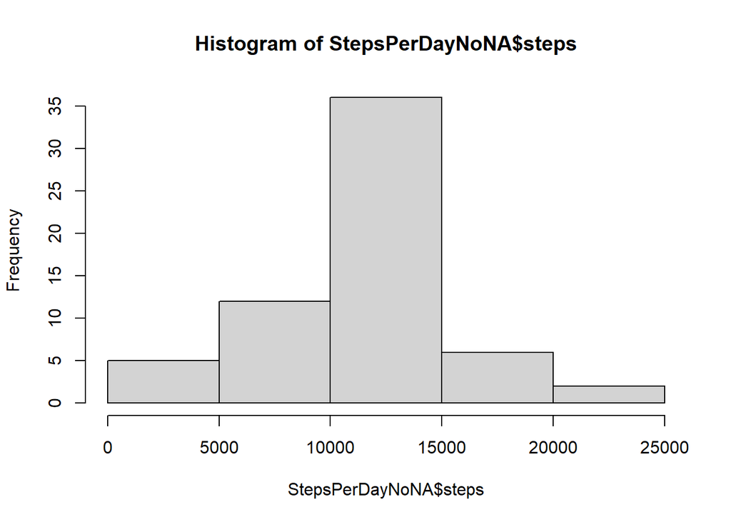

```r
StepsPerDayNoNA <- aggregate(steps ~ date, data=dataNoNA, sum)
hist(StepsPerDayNoNA$steps)
```

```r
meanStepsPerDayNoNA <- mean(StepsPerDayNoNA$steps)
medianStepsPerDayNoNA <- median(StepsPerDayNoNA$steps)
```

## 5.Are there differences in activity patterns between weekdays and weekends?

a.Create a new factor variable in the dataset with two levels – “weekday” and “weekend” indicating whether a given date is a weekday or weekend day.

```r
dataNoNA$date <- as.Date(strptime(dataNoNA$date, format="%Y-%m-%d"))
dataNoNA$day <- weekdays(dataNoNA$date)
for (i in 1:nrow(dataNoNA)) {
    if (dataNoNA[i,]$day %in% c("Saturday","Sunday")) {
        dataNoNA[i,]$day<-"weekend"
    }
    else{
        dataNoNA[i,]$day<-"weekday"
    }
}
stepsByDay <- aggregate(dataNoNA$steps ~ dataNoNA$interval + dataNoNA$day, dataNoNA, mean)
```

b.Make a panel plot containing a time series plot (i.e. 𝚝𝚢𝚙𝚎 = “𝚕”) of the 5-minute interval (x-axis) and the average number of steps taken, averaged across all weekday days or weekend days (y-axis). See the README file in the GitHub repository to see an example of what this plot should look like using simulated data.

[figure not shown]

```r
library(lattice)
names(stepsByDay) <- c("interval", "day", "steps")
xyplot(steps ~ interval | day, stepsByDay, type = "l", layout = c(1, 2),
    xlab = "Interval", ylab = "Number of steps")
```